# MDA2025-U10-Losungen

## 10. Übungsblatt SoSe 2025

### Dreifachintegrale

1. Berechne folgende Dreifachintegrale.
- $\int_{x=0}^{1} \int_{y=-1}^{4} \int_{z=0}^\pi x^2 y \cos(yz) \mathrm{d}{z} \mathrm{d}{y}\mathrm{d}{x}$
- $\int_{\varphi=\pi}^{2 \pi} \int_{r=0}^{1} \int_{z=r}^{r^2} rz \sin(\varphi) \mathrm{d}{z} \mathrm{d}{r}\mathrm{d}{\varphi}$
- $\int_{\varphi=\pi}^{2 \pi} \int_{\vartheta=0}^{\pi} \int_{r=0}^{R} k r^3 \sin(\vartheta) \mathrm{d}{r} \mathrm{d}{\vartheta}\mathrm{d}{\varphi}$
2. Bestimme das Volumen des Kegels in Abbildung mit Hilfe eines Dreifachintegrals:

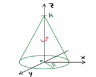

3. Welches Volumen hat ein Körper, der bei der Rotation von

$$ z(x) = \dfrac{b}{a} \sqrt{a^2 - x^2} \, \quad a > 0, \,b > 0, \, 0 \le x \le a $$

um die z-Achse entsteht?

4. Welches Massenträgheitsmoment hat eine Kugel (Radius $R$) bezüglich einer Tangente als Drehachse?

#### Lösung

*1a)*

kartesische Koordinaten:

$\int_{z=0}^\pi x^2 y \cos(yz) \mathrm{d}{z} = x^2y\int_{z=0}^\pi \cos(yz) \mathrm{d}{z} = x^2y \left[\dfrac{\sin(yz)}{y}\right]_0^\pi = x^2y\left[ \dfrac{\sin(y\pi)}{y}-\dfrac{\overbrace{\sin(0)}^0}{y} \right] = x^2 \sin(y\pi) $

$\int_{y=-1}^{4} x^2 \sin(y\pi) \mathrm{d}{y} = x^2\int_{y=-1}^{4} \sin(y\pi) \mathrm{d}{y} = x^2 \left[-\dfrac{\cos(y\pi)}{\pi}\right]_{-1}^4 = -\dfrac{x^2}{\pi}\left[\overbrace{\cos(4\pi)}^1-\overbrace{\cos(-\pi)}^{-1}\right] = -\dfrac{2x^2}{\pi} $

$\int_{x=0}^{1} -\dfrac{2x^2}{\pi}\mathrm{d}{x} = -\dfrac{2}{\pi} \int_{x=0}^{1} x^2\mathrm{d}{x} = -\dfrac{2}{\pi} \left[\dfrac{x^3}{3}\right]_0^1 = -\dfrac{2}{\pi} \left[\dfrac{1}{3}-0\right] = \underline{\underline{-\dfrac{2}{3\pi}}}$

*1b)*

zylindrische Koordinaten:

$\int_{z=r}^{r^2} rz \sin(\varphi) \mathrm{d}{z} = r \sin(\varphi)\int_{z=r}^{r^2} z \mathrm{d}{z} = r \sin(\varphi) \left[\dfrac{z^2}{2}\right]_r^{r^2} = r \sin(\varphi) \left[\dfrac{r^4-r^2}{2}\right] = \sin(\varphi) \dfrac{r^5 - r^3}{2}$

$\int_{r=0}^{1} \sin(\varphi)\dfrac{r^5 - r^3}{2}\mathrm{d}{r} = \dfrac{\sin(\varphi)}{2}\int_{r=0}^{1} r^5 - r^3\mathrm{d}{r} = \dfrac{\sin(\varphi)}{2} \left[\dfrac{r^6}{6} - \dfrac{r^4}{4}\right]_0^1 = \dfrac{\sin(\varphi)}{2} \left[\dfrac{1}{6} - \dfrac{1}{4}\right] = -\dfrac{\sin(\varphi)}{24} $

$\int_{\varphi=\pi}^{2 \pi} -\dfrac{\sin(\varphi)}{24} \mathrm{d}{\varphi} =-\dfrac{1}{24}\int_{\varphi=\pi}^{2 \pi} \sin(\varphi) \mathrm{d}{\varphi} = -\dfrac{1}{24} \left[-\cos(\varphi)\right]_{\pi}^{2 \pi} = \underline{\underline{\dfrac{1}{12}}}$

*1c)*

sphärische Koordinaten:

$\int_{r=0}^{R} k r^3 \sin(\vartheta) \mathrm{d}{r} = k\sin(\vartheta)\int_{r=0}^{R} r^3 \mathrm{d}{r} = k \sin(\vartheta)\left[\dfrac{r^4}{4}\right]_0^R =k \sin(\vartheta)\dfrac{R^4}{4}$

$\int_{\vartheta=0}^{\pi} k\sin(\vartheta)\dfrac{R^4}{4} \mathrm{d}{\vartheta} =\dfrac{kR^4}{4}\int_{\vartheta=0}^{\pi} \sin(\vartheta) \mathrm{d}{\vartheta} = \dfrac{kR^4}{4}\left[-\cos(\vartheta)\right]_0^{\pi} = \dfrac{kR^4}{2}$

$\int_{\varphi=\pi}^{2 \pi} \dfrac{kR^4}{2} \mathrm{d}{\varphi} =\dfrac{kR^4}{2} \int_{\varphi=\pi}^{2 \pi} \mathrm{d}{\varphi} =\dfrac{kR^4}{2} \left[ \varphi\right]_{\pi}^{2\pi} = \underline{\underline{\dfrac{kR^4\pi}{2}}}$

*2)*

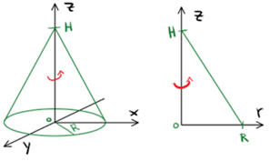

Der Bereich wird durch die Koordinaten $r$ und $z$ beschrieben, wie im rechten Bild dargestellt. In diesem Fall läuft die Koordinate $r$ von $0$ bis $R$, und die Koordinate $z$ von $0$ bis zur Geraden, die den Bereich begrenzt.

Die Gerade wird durch die zwei Punkte $[0,H]$ und $[R,0]$ definiert. Um die Gleichung der Geraden in der Form $z=ar+b$ zu bestimmen, setzen wir die beiden Punkte ein:
$$[0,H]\Rightarrow H = a\cdot0+b \Rightarrow b=H$$ $$[R,0]\Rightarrow 0 = a\cdot R+b \Rightarrow a = -\cfrac{b}{R} = -\cfrac{H}{R}$$ Daraus ergibt sich die Geradengleichung: $$z = H-\cfrac{H}{R}r$$ Integrationsgrenzen: $$0\leq\varphi\leq 2\pi,\;\;\; 0\leq r\leq R,\;\;\; 0\leq z\leq H-\cfrac{H}{R}r$$

Und wir können das Volumen des Kegels als Dreifachintegral berechnen (zylindrische Koordinaten): $$V = \int\int\int dV = \int_{\varphi=0}^{2\pi} \int_{r=0}^R \int_{z=0}^{H-\cfrac{H}{R}r} r dzdrd\varphi$$

$\int_{z=0}^{H-\cfrac{H}{R}r} r dz = r\int_{z=0}^{H-\cfrac{H}{R}r} dz = r\left[z \right]_{0}^{H-\cfrac{H}{R}r} = r\left(H-\cfrac{H}{R}r\right) $

$\int_{r=0}^R r\left(H-\cfrac{H}{R}r\right) dr = H\int_{r=0}^R \left(r-\cfrac{r^2}{R}\right) dr = H \left[\dfrac{r^2}{2}-\cfrac{r^3}{3R}\right]_0^R = H \left[\dfrac{R^2}{2}-\cfrac{R^3}{3R}\right] = HR^2 \left[\cfrac{1}{2}-\cfrac{1}{3}\right] = \cfrac{HR^2}{6} $

$\int_{\varphi=0}^{2\pi} \cfrac{HR^2}{6} d\varphi = \cfrac{HR^2}{6}\int_{\varphi=0}^{2\pi} d\varphi = \cfrac{HR^2}{6}2\pi = \underline{\underline{\cfrac13 \pi R^2 H}}$

*3)*

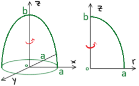

In diesem Fall ist die Funktion, die den Bereich begrenzt $$z(r)= \cfrac{b}{a}\sqrt{a^2-r^2} $$ Integrationsgrenzen $$0\leq\varphi\leq2\pi,\;\;\; 0\leq r\leq a,\;\;\; 0\leq z\leq \cfrac{b}{a}\sqrt{a^2-r^2}$$

und $$V = \int\int\int dV = \int_{\varphi=0}^{2\pi} \int_{r=0}^a \int_{z=0}^{\cfrac{b}{a}\sqrt{a^2-r^2}} r dzdrd\varphi$$ $\int_{z=0}^{\cfrac{b}{a}\sqrt{a^2-r^2}} r dz = r\int_{z=0}^{\cfrac{b}{a}\sqrt{a^2-r^2}} dz = r[z]_{z=0}^{\cfrac{b}{a}\sqrt{a^2-r^2}} = r\cfrac{b}{a}\sqrt{a^2-r^2}$

$\int_{r=0}^a r\cfrac{b}{a}\sqrt{a^2-r^2} dr = \cfrac{b}{a} \left[ -\cfrac13 (a^2-r^2)^{3/2} \right]_0^a = \cfrac{b}{a}\left[ \cfrac13(a^2)^{3/2}\right] = \cfrac{ba^2}{3}$

$\int_{\varphi=0}^{2\pi} \cfrac{ba^2}{3}d\varphi = \cfrac{ba^2}{3}\int_{\varphi=0}^{2\pi} d\varphi = \underline{\underline{\cfrac23\pi ba^2}}$

*4)*

Für die Berechnung des Massenträgheitsmoment gilt

$$J = \varrho \int\int\int r_A^2 \mathrm{d}V$$

mit $r_A$ als *senkrechter* Abstand zur Drehachse. Es bietet sich daher eine Berechnung in *Zylinderkoordinaten* an.

Die Grenzen der Integrale sind

- Winkel: $0 \le \varphi \le 2 \pi$
- Radius (senkrechter Abstand von der Symmetrieachse): $0 \le r \le R$
- Höhe: $-\sqrt{R^2-r^2} \le z \le \sqrt{R^2-r^2}$

es ergibt sich das Integral

$ \int_{\varphi=0}^{2\pi} \int_{r=0}^R \int_{z=-\sqrt{R^2-r^2}}^{\sqrt{R^2-r^2}} r^2 \cdot r \mathrm{d}z\mathrm{d}r\mathrm{d}\varphi $

$\int_{z=-\sqrt{R^2-r^2}}^{\sqrt{R^2-r^2}} r^2 \cdot r \mathrm{d}z = 2r^3\sqrt{R^2-r^2}$

$\int_{r=0}^R 2r^3\sqrt{R^2-r^2} \mathrm{d}r = 2 \left(\dfrac{1}{5} \sqrt{(R^2 - r^2)^5} - \dfrac{R^2}{3}\sqrt{(R^2 - r^2)^3} \right)_0^R = 2 \left(-\dfrac{R^5}{5} + \dfrac{R^5}{3}\right) = \dfrac{4 R^5}{15}$

$\int_{\varphi=0}^{2\pi} \dfrac{4 R^5}{15}\mathrm{d}\varphi = \dfrac{8 \pi R^5}{15}$

Massenträgheitsmoment mit Drehachse durch den Ursprung:

$J = \dfrac{8}{15}\varrho\pi R^5$

Drehachse ist eine Tangente an die Kugel (Abstand ist $R$):

Satz von Steiner: $J_T = J + mR^2$

Masse der Kugel: $m = \varrho V = \varrho \dfrac{4}{3}\pi R^3$

$J_T = \dfrac{8}{15}\varrho\pi R^5 + mR^2 = \dfrac{2}{5}mR^2 + mR^2 = \dfrac{7}{5}mR^2$

#### Hinweise

Grundintegrale:

für jede Funktion $f$ mit Stammfunktion $F$:

$\int f(cx) dx = \int \dfrac{f(u)}{c}du = \dfrac{F(u)}{c} = \dfrac{F(cx)}{c}$ (substitution $u=cx \Rightarrow du = c dx$)

$\int r\sqrt{a^2-r^2}dr = -\cfrac{1}{2}\int \sqrt{u}du = -\cfrac12 \cfrac{u^\cfrac{3}{2}}{\cfrac{3}{2}} = -\cfrac{1}{3} (a^2-r^2)^{3/2}$ (substitution $u=a^2-r^2$)

Zylinderkoordinaten: $$\begin{array}{rcl} x&=&r\cos\varphi,\\ y&=&r\sin\varphi,\\ z&=&z,\\ dV&=&rdrd\varphi dz\end{array}$$

Massenträgheitsmoment $J = \varrho \int\int\int r_A^2 \mathrm{d}V$ mit $r_A$ als *senkrechter* Abstand zur Drehachse.

Satz von Steiner: $J = J_{Schwerpunkt} + md^2$.  
$d$ ist Abstand zwischen der Schwerpunktachse und der neuen Achse.